# Risk Factor Analysis

## Outcome Variable

**Outcome Variable:** y_rate_haz

## Predictor Variables

**Intervention Variable:** single

**Adjustment Set:**

unadjusted

## Stratifying Variables

The analysis was stratified on these variable(s):

- agecat
- studyid
- country

## Data Summary

| agecat | studyid | country | single | n_cell | n |
| --- | --- | --- | --- | --- | --- |
| 0-3 months | ki0047075b-MAL-ED | BANGLADESH | 0 | 244 | 244 |
| 0-3 months | ki1119695-PROBIT | BELARUS | 0 | 12251 | 12745 |
| 0-3 months | ki1119695-PROBIT | BELARUS | 1 | 494 | 12745 |
| 0-3 months | ki0047075b-MAL-ED | BRAZIL | 0 | 157 | 180 |
| 0-3 months | ki0047075b-MAL-ED | BRAZIL | 1 | 23 | 180 |
| 0-3 months | ki1135781-COHORTS | GUATEMALA | 0 | 632 | 676 |
| 0-3 months | ki1135781-COHORTS | GUATEMALA | 1 | 44 | 676 |
| 0-3 months | ki0047075b-MAL-ED | INDIA | 0 | 200 | 200 |
| 0-3 months | ki1135781-COHORTS | INDIA | 0 | 4655 | 4662 |
| 0-3 months | ki1135781-COHORTS | INDIA | 1 | 7 | 4662 |
| 0-3 months | ki0047075b-MAL-ED | NEPAL | 0 | 175 | 175 |
| 0-3 months | ki0047075b-MAL-ED | PERU | 0 | 238 | 271 |
| 0-3 months | ki0047075b-MAL-ED | PERU | 1 | 33 | 271 |
| 0-3 months | ki0047075b-MAL-ED | SOUTH AFRICA | 0 | 131 | 229 |
| 0-3 months | ki0047075b-MAL-ED | SOUTH AFRICA | 1 | 98 | 229 |
| 0-3 months | ki0047075b-MAL-ED | TANZANIA, UNITED REPUBLIC OF | 0 | 220 | 229 |
| 0-3 months | ki0047075b-MAL-ED | TANZANIA, UNITED REPUBLIC OF | 1 | 9 | 229 |
| 0-3 months | ki1126311-ZVITAMBO | ZIMBABWE | 0 | 7344 | 7835 |
| 0-3 months | ki1126311-ZVITAMBO | ZIMBABWE | 1 | 491 | 7835 |
| 3-6 months | ki0047075b-MAL-ED | BANGLADESH | 0 | 231 | 231 |
| 3-6 months | ki1119695-PROBIT | BELARUS | 0 | 12773 | 13309 |
| 3-6 months | ki1119695-PROBIT | BELARUS | 1 | 536 | 13309 |
| 3-6 months | ki0047075b-MAL-ED | BRAZIL | 0 | 178 | 208 |
| 3-6 months | ki0047075b-MAL-ED | BRAZIL | 1 | 30 | 208 |
| 3-6 months | ki1135781-COHORTS | GUATEMALA | 0 | 696 | 754 |
| 3-6 months | ki1135781-COHORTS | GUATEMALA | 1 | 58 | 754 |
| 3-6 months | ki0047075b-MAL-ED | INDIA | 0 | 227 | 227 |
| 3-6 months | ki1135781-COHORTS | INDIA | 0 | 4711 | 4719 |
| 3-6 months | ki1135781-COHORTS | INDIA | 1 | 8 | 4719 |
| 3-6 months | ki0047075b-MAL-ED | NEPAL | 0 | 233 | 233 |

[output cut: 57 more lines]

The following strata were considered:

- agecat: 0-3 months, studyid: ki0047075b-MAL-ED, country: BANGLADESH
- agecat: 0-3 months, studyid: ki0047075b-MAL-ED, country: BRAZIL
- agecat: 0-3 months, studyid: ki0047075b-MAL-ED, country: INDIA
- agecat: 0-3 months, studyid: ki0047075b-MAL-ED, country: NEPAL
- agecat: 0-3 months, studyid: ki0047075b-MAL-ED, country: PERU
- agecat: 0-3 months, studyid: ki0047075b-MAL-ED, country: SOUTH AFRICA
- agecat: 0-3 months, studyid: ki0047075b-MAL-ED, country: TANZANIA, UNITED REPUBLIC OF
- agecat: 0-3 months, studyid: ki1119695-PROBIT, country: BELARUS
- agecat: 0-3 months, studyid: ki1126311-ZVITAMBO, country: ZIMBABWE
- agecat: 0-3 months, studyid: ki1135781-COHORTS, country: GUATEMALA
- agecat: 0-3 months, studyid: ki1135781-COHORTS, country: INDIA
- agecat: 12-24 months, studyid: ki0047075b-MAL-ED, country: BANGLADESH
- agecat: 12-24 months, studyid: ki0047075b-MAL-ED, country: BRAZIL
- agecat: 12-24 months, studyid: ki0047075b-MAL-ED, country: INDIA
- agecat: 12-24 months, studyid: ki0047075b-MAL-ED, country: NEPAL
- agecat: 12-24 months, studyid: ki0047075b-MAL-ED, country: PERU
- agecat: 12-24 months, studyid: ki0047075b-MAL-ED, country: SOUTH AFRICA
- agecat: 12-24 months, studyid: ki0047075b-MAL-ED, country: TANZANIA, UNITED REPUBLIC OF
- agecat: 12-24 months, studyid: ki1066203-TanzaniaChild2, country: TANZANIA, UNITED REPUBLIC OF
- agecat: 12-24 months, studyid: ki1119695-PROBIT, country: BELARUS
- agecat: 12-24 months, studyid: ki1126311-ZVITAMBO, country: ZIMBABWE
- agecat: 12-24 months, studyid: ki1135781-COHORTS, country: GUATEMALA
- agecat: 12-24 months, studyid: ki1135781-COHORTS, country: INDIA
- agecat: 12-24 months, studyid: ki1135781-COHORTS, country: PHILIPPINES
- agecat: 3-6 months, studyid: ki0047075b-MAL-ED, country: BANGLADESH
- agecat: 3-6 months, studyid: ki0047075b-MAL-ED, country: BRAZIL
- agecat: 3-6 months, studyid: ki0047075b-MAL-ED, country: INDIA
- agecat: 3-6 months, studyid: ki0047075b-MAL-ED, country: NEPAL
- agecat: 3-6 months, studyid: ki0047075b-MAL-ED, country: PERU
- agecat: 3-6 months, studyid: ki0047075b-MAL-ED, country: SOUTH AFRICA
- agecat: 3-6 months, studyid: ki0047075b-MAL-ED, country: TANZANIA, UNITED REPUBLIC OF
- agecat: 3-6 months, studyid: ki1066203-TanzaniaChild2, country: TANZANIA, UNITED REPUBLIC OF
- agecat: 3-6 months, studyid: ki1119695-PROBIT, country: BELARUS
- agecat: 3-6 months, studyid: ki1126311-ZVITAMBO, country: ZIMBABWE
- agecat: 3-6 months, studyid: ki1135781-COHORTS, country: GUATEMALA
- agecat: 3-6 months, studyid: ki1135781-COHORTS, country: INDIA
- agecat: 6-12 months, studyid: ki0047075b-MAL-ED, country: BANGLADESH
- agecat: 6-12 months, studyid: ki0047075b-MAL-ED, country: BRAZIL
- agecat: 6-12 months, studyid: ki0047075b-MAL-ED, country: INDIA
- agecat: 6-12 months, studyid: ki0047075b-MAL-ED, country: NEPAL
- agecat: 6-12 months, studyid: ki0047075b-MAL-ED, country: PERU
- agecat: 6-12 months, studyid: ki0047075b-MAL-ED, country: SOUTH AFRICA
- agecat: 6-12 months, studyid: ki0047075b-MAL-ED, country: TANZANIA, UNITED REPUBLIC OF
- agecat: 6-12 months, studyid: ki1066203-TanzaniaChild2, country: TANZANIA, UNITED REPUBLIC OF
- agecat: 6-12 months, studyid: ki1112895-Guatemala BSC, country: GUATEMALA
- agecat: 6-12 months, studyid: ki1119695-PROBIT, country: BELARUS
- agecat: 6-12 months, studyid: ki1126311-ZVITAMBO, country: ZIMBABWE
- agecat: 6-12 months, studyid: ki1135781-COHORTS, country: GUATEMALA
- agecat: 6-12 months, studyid: ki1135781-COHORTS, country: INDIA
- agecat: 6-12 months, studyid: ki1135781-COHORTS, country: PHILIPPINES

## Methods Detail

We’re interested in the causal parameters $E[Y_a]$ for all values of $a \in \mathcal{A}$. These parameters represent the mean outcome if, possibly contrary to fact, we intervened to set all units to have $A=a$. Under the randomization and positivity assumptions, these are identified by the statistical parameters $\psi_a=E_W[E_{Y|A,W}(Y|A=a,W)]$. In addition, we’re interested in the mean of $Y$, $E[Y]$ under no intervention (the observed mean). We will estimate these parameters by using SuperLearner to fit the relevant likelihood factors – $E_{Y|A,W}(Y|A=a,W)$ and $p(A=a|W)$, and then updating our likelihood fit using a joint TMLE.

For unadjusted analyses ($W=\{\}$), initial likelihoods were estimated using Lrnr_glm to estimate the simple $E(Y|A)$ and Lrnr_mean to estimate $p(A)$. For adjusted analyses, a small library containing Lrnr_glmnet, Lrnr_xgboost, and Lrnr_mean was used.

Having estimated these parameters, we will then use the delta method to estimate relative risks and attributable risks relative to a prespecified baseline level of $A$.

[output not shown]

[output cut: 3045 more lines]

[output not shown]

# Results Detail

## Results Plots

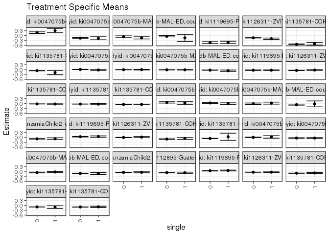

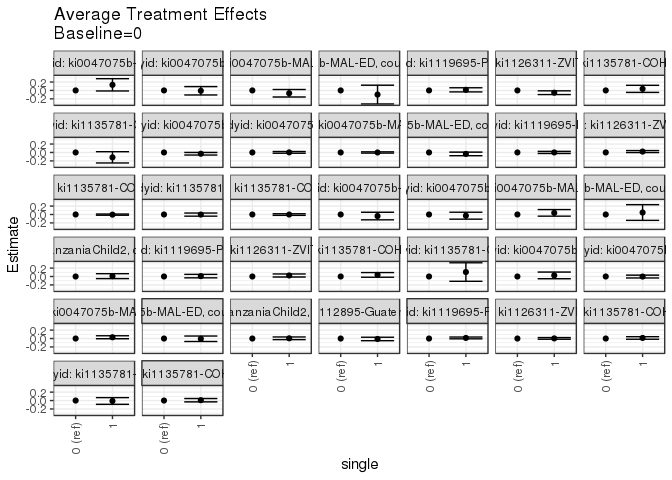

## Results Table

### Parameter: TSM

| agecat | studyid | country | intervention_level | baseline_level | estimate | ci_lower | ci_upper |
| --- | --- | --- | --- | --- | --- | --- | --- |
| 0-3 months | ki0047075b-MAL-ED | BRAZIL | 0 | NA | 0.1758635 | 0.1201756 | 0.2315515 |
| 0-3 months | ki0047075b-MAL-ED | BRAZIL | 1 | NA | 0.3088689 | 0.1738029 | 0.4439349 |
| 0-3 months | ki0047075b-MAL-ED | PERU | 0 | NA | -0.1570633 | -0.1917683 | -0.1223582 |
| 0-3 months | ki0047075b-MAL-ED | PERU | 1 | NA | -0.1656470 | -0.2587264 | -0.0725677 |
| 0-3 months | ki0047075b-MAL-ED | SOUTH AFRICA | 0 | NA | -0.0732280 | -0.1302430 | -0.0162130 |
| 0-3 months | ki0047075b-MAL-ED | SOUTH AFRICA | 1 | NA | -0.1401766 | -0.2083770 | -0.0719761 |
| 0-3 months | ki0047075b-MAL-ED | TANZANIA, UNITED REPUBLIC OF | 0 | NA | -0.0422918 | -0.0813576 | -0.0032261 |
| 0-3 months | ki0047075b-MAL-ED | TANZANIA, UNITED REPUBLIC OF | 1 | NA | -0.1408850 | -0.3605068 | 0.0787368 |
| 0-3 months | ki1119695-PROBIT | BELARUS | 0 | NA | -0.4381530 | -0.4974706 | -0.3788353 |
| 0-3 months | ki1119695-PROBIT | BELARUS | 1 | NA | -0.4236278 | -0.4999923 | -0.3472634 |
| 0-3 months | ki1126311-ZVITAMBO | ZIMBABWE | 0 | NA | -0.1388945 | -0.1496186 | -0.1281703 |
| 0-3 months | ki1126311-ZVITAMBO | ZIMBABWE | 1 | NA | -0.1927413 | -0.2354914 | -0.1499912 |
| 0-3 months | ki1135781-COHORTS | GUATEMALA | 0 | NA | -0.5407885 | -0.5645570 | -0.5170201 |
| 0-3 months | ki1135781-COHORTS | GUATEMALA | 1 | NA | -0.5034292 | -0.5843461 | -0.4225123 |
| 0-3 months | ki1135781-COHORTS | INDIA | 0 | NA | -0.0694702 | -0.0777192 | -0.0612212 |
| 0-3 months | ki1135781-COHORTS | INDIA | 1 | NA | -0.1853970 | -0.3193588 | -0.0514352 |
| 3-6 months | ki0047075b-MAL-ED | BRAZIL | 0 | NA | 0.0658306 | 0.0253954 | 0.1062658 |
| 3-6 months | ki0047075b-MAL-ED | BRAZIL | 1 | NA | 0.0288050 | -0.0512251 | 0.1088351 |
| 3-6 months | ki0047075b-MAL-ED | PERU | 0 | NA | 0.0308326 | -0.0028782 | 0.0645434 |
| 3-6 months | ki0047075b-MAL-ED | PERU | 1 | NA | 0.0020274 | -0.0728298 | 0.0768847 |
| 3-6 months | ki0047075b-MAL-ED | SOUTH AFRICA | 0 | NA | -0.0173407 | -0.0644272 | 0.0297458 |
| 3-6 months | ki0047075b-MAL-ED | SOUTH AFRICA | 1 | NA | 0.0212370 | -0.0410293 | 0.0835033 |
| 3-6 months | ki0047075b-MAL-ED | TANZANIA, UNITED REPUBLIC OF | 0 | NA | -0.0721021 | -0.1047651 | -0.0394391 |
| 3-6 months | ki0047075b-MAL-ED | TANZANIA, UNITED REPUBLIC OF | 1 | NA | -0.0255782 | -0.2091445 | 0.1579880 |
| 3-6 months | ki1066203-TanzaniaChild2 | TANZANIA, UNITED REPUBLIC OF | 0 | NA | -0.0867435 | -0.1041956 | -0.0692913 |
| 3-6 months | ki1066203-TanzaniaChild2 | TANZANIA, UNITED REPUBLIC OF | 1 | NA | -0.0785085 | -0.1339253 | -0.0230917 |
| 3-6 months | ki1119695-PROBIT | BELARUS | 0 | NA | 0.0466978 | 0.0271747 | 0.0662210 |
| 3-6 months | ki1119695-PROBIT | BELARUS | 1 | NA | 0.0561385 | 0.0145471 | 0.0977299 |
| 3-6 months | ki1126311-ZVITAMBO | ZIMBABWE | 0 | NA | -0.0023000 | -0.0120036 | 0.0074037 |
| 3-6 months | ki1126311-ZVITAMBO | ZIMBABWE | 1 | NA | 0.0221901 | -0.0124671 | 0.0568473 |
| 3-6 months | ki1135781-COHORTS | GUATEMALA | 0 | NA | -0.1020783 | -0.1177274 | -0.0864293 |
| 3-6 months | ki1135781-COHORTS | GUATEMALA | 1 | NA | -0.0636022 | -0.1167892 | -0.0104152 |
| 3-6 months | ki1135781-COHORTS | INDIA | 0 | NA | -0.0632424 | -0.0696888 | -0.0567960 |
| 3-6 months | ki1135781-COHORTS | INDIA | 1 | NA | 0.0429801 | -0.1774334 | 0.2633936 |
| 6-12 months | ki0047075b-MAL-ED | BRAZIL | 0 | NA | 0.0029346 | -0.0159187 | 0.0217878 |
| 6-12 months | ki0047075b-MAL-ED | BRAZIL | 1 | NA | 0.0290158 | -0.0478905 | 0.1059220 |
| 6-12 months | ki0047075b-MAL-ED | PERU | 0 | NA | -0.0371661 | -0.0526142 | -0.0217180 |
| 6-12 months | ki0047075b-MAL-ED | PERU | 1 | NA | -0.0383639 | -0.0684019 | -0.0083258 |
| 6-12 months | ki0047075b-MAL-ED | SOUTH AFRICA | 0 | NA | -0.0673545 | -0.0893485 | -0.0453605 |
| 6-12 months | ki0047075b-MAL-ED | SOUTH AFRICA | 1 | NA | -0.0367618 | -0.0641009 | -0.0094226 |
| 6-12 months | ki0047075b-MAL-ED | TANZANIA, UNITED REPUBLIC OF | 0 | NA | -0.1238574 | -0.1398522 | -0.1078625 |
| 6-12 months | ki0047075b-MAL-ED | TANZANIA, UNITED REPUBLIC OF | 1 | NA | -0.1296884 | -0.1924653 | -0.0669116 |
| 6-12 months | ki1066203-TanzaniaChild2 | TANZANIA, UNITED REPUBLIC OF | 0 | NA | -0.0599673 | -0.0696358 | -0.0502987 |
| 6-12 months | ki1066203-TanzaniaChild2 | TANZANIA, UNITED REPUBLIC OF | 1 | NA | -0.0545627 | -0.0846510 | -0.0244744 |
| 6-12 months | ki1112895-Guatemala BSC | GUATEMALA | 0 | NA | -0.0741953 | -0.0879960 | -0.0603946 |
| 6-12 months | ki1112895-Guatemala BSC | GUATEMALA | 1 | NA | -0.0844451 | -0.1230531 | -0.0458371 |
| 6-12 months | ki1119695-PROBIT | BELARUS | 0 | NA | 0.0417357 | 0.0251523 | 0.0583192 |
| 6-12 months | ki1119695-PROBIT | BELARUS | 1 | NA | 0.0559040 | 0.0297270 | 0.0820809 |
| 6-12 months | ki1126311-ZVITAMBO | ZIMBABWE | 0 | NA | -0.0494491 | -0.0542779 | -0.0446203 |
| 6-12 months | ki1126311-ZVITAMBO | ZIMBABWE | 1 | NA | -0.0466473 | -0.0651053 | -0.0281894 |
| 6-12 months | ki1135781-COHORTS | GUATEMALA | 0 | NA | -0.1113434 | -0.1189387 | -0.1037482 |
| 6-12 months | ki1135781-COHORTS | GUATEMALA | 1 | NA | -0.0974863 | -0.1266659 | -0.0683068 |
| 6-12 months | ki1135781-COHORTS | INDIA | 0 | NA | -0.0961828 | -0.1002224 | -0.0921433 |
| 6-12 months | ki1135781-COHORTS | INDIA | 1 | NA | -0.1061242 | -0.1857341 | -0.0265143 |
| 6-12 months | ki1135781-COHORTS | PHILIPPINES | 0 | NA | -0.1002776 | -0.1054489 | -0.0951062 |
| 6-12 months | ki1135781-COHORTS | PHILIPPINES | 1 | NA | -0.0917469 | -0.1309218 | -0.0525719 |
| 12-24 months | ki0047075b-MAL-ED | BRAZIL | 0 | NA | 0.0025932 | -0.0086937 | 0.0138801 |
| 12-24 months | ki0047075b-MAL-ED | BRAZIL | 1 | NA | -0.0280085 | -0.0563463 | 0.0003294 |
| 12-24 months | ki0047075b-MAL-ED | PERU | 0 | NA | -0.0094792 | -0.0170461 | -0.0019122 |
| 12-24 months | ki0047075b-MAL-ED | PERU | 1 | NA | -0.0076256 | -0.0260596 | 0.0108083 |
| 12-24 months | ki0047075b-MAL-ED | SOUTH AFRICA | 0 | NA | -0.0152579 | -0.0249094 | -0.0056065 |
| 12-24 months | ki0047075b-MAL-ED | SOUTH AFRICA | 1 | NA | -0.0154532 | -0.0275023 | -0.0034040 |
| 12-24 months | ki0047075b-MAL-ED | TANZANIA, UNITED REPUBLIC OF | 0 | NA | -0.0383288 | -0.0462417 | -0.0304160 |
| 12-24 months | ki0047075b-MAL-ED | TANZANIA, UNITED REPUBLIC OF | 1 | NA | -0.0727493 | -0.1142883 | -0.0312102 |
| 12-24 months | ki1119695-PROBIT | BELARUS | 0 | NA | -0.0430655 | -0.0607657 | -0.0253653 |
| 12-24 months | ki1119695-PROBIT | BELARUS | 1 | NA | -0.0425647 | -0.0630459 | -0.0220836 |
| 12-24 months | ki1126311-ZVITAMBO | ZIMBABWE | 0 | NA | -0.0537462 | -0.0635987 | -0.0438937 |
| 12-24 months | ki1126311-ZVITAMBO | ZIMBABWE | 1 | NA | -0.0328213 | -0.0547497 | -0.0108930 |
| 12-24 months | ki1135781-COHORTS | GUATEMALA | 0 | NA | -0.0293424 | -0.0332750 | -0.0254098 |
| 12-24 months | ki1135781-COHORTS | GUATEMALA | 1 | NA | -0.0332780 | -0.0466422 | -0.0199139 |
| 12-24 months | ki1135781-COHORTS | INDIA | 0 | NA | -0.0358765 | -0.0378050 | -0.0339480 |
| 12-24 months | ki1135781-COHORTS | INDIA | 1 | NA | -0.0383325 | -0.0756637 | -0.0010013 |
| 12-24 months | ki1135781-COHORTS | PHILIPPINES | 0 | NA | -0.0579582 | -0.0605220 | -0.0553943 |
| 12-24 months | ki1135781-COHORTS | PHILIPPINES | 1 | NA | -0.0593711 | -0.0779510 | -0.0407911 |

### Parameter: E(Y)

| agecat | studyid | country | intervention_level | baseline_level | estimate | ci_lower | ci_upper |
| --- | --- | --- | --- | --- | --- | --- | --- |
| 0-3 months | ki0047075b-MAL-ED | BRAZIL | NA | NA | 0.1928587 | 0.1409027 | 0.2448147 |
| 0-3 months | ki0047075b-MAL-ED | PERU | NA | NA | -0.1581085 | -0.1906285 | -0.1255886 |
| 0-3 months | ki0047075b-MAL-ED | SOUTH AFRICA | NA | NA | -0.1018785 | -0.1458569 | -0.0579001 |
| 0-3 months | ki0047075b-MAL-ED | TANZANIA, UNITED REPUBLIC OF | NA | NA | -0.0461667 | -0.0847570 | -0.0075763 |
| 0-3 months | ki1119695-PROBIT | BELARUS | NA | NA | -0.4375900 | -0.4969173 | -0.3782626 |
| 0-3 months | ki1126311-ZVITAMBO | ZIMBABWE | NA | NA | -0.1422689 | -0.1526759 | -0.1318619 |
| 0-3 months | ki1135781-COHORTS | GUATEMALA | NA | NA | -0.5383569 | -0.5612045 | -0.5155093 |
| 0-3 months | ki1135781-COHORTS | INDIA | NA | NA | -0.0696442 | -0.0778843 | -0.0614041 |
| 3-6 months | ki0047075b-MAL-ED | BRAZIL | NA | NA | 0.0604904 | 0.0239698 | 0.0970111 |
| 3-6 months | ki0047075b-MAL-ED | PERU | NA | NA | 0.0273803 | -0.0036374 | 0.0583980 |
| 3-6 months | ki0047075b-MAL-ED | SOUTH AFRICA | NA | NA | -0.0000528 | -0.0382594 | 0.0381539 |
| 3-6 months | ki0047075b-MAL-ED | TANZANIA, UNITED REPUBLIC OF | NA | NA | -0.0705448 | -0.1027245 | -0.0383652 |
| 3-6 months | ki1066203-TanzaniaChild2 | TANZANIA, UNITED REPUBLIC OF | NA | NA | -0.0860053 | -0.1026518 | -0.0693587 |
| 3-6 months | ki1119695-PROBIT | BELARUS | NA | NA | 0.0470780 | 0.0278572 | 0.0662989 |
| 3-6 months | ki1126311-ZVITAMBO | ZIMBABWE | NA | NA | -0.0007769 | -0.0101301 | 0.0085763 |
| 3-6 months | ki1135781-COHORTS | GUATEMALA | NA | NA | -0.0991186 | -0.1141500 | -0.0840873 |
| 3-6 months | ki1135781-COHORTS | INDIA | NA | NA | -0.0630623 | -0.0695098 | -0.0566148 |
| 6-12 months | ki0047075b-MAL-ED | BRAZIL | NA | NA | 0.0065644 | -0.0129183 | 0.0260472 |
| 6-12 months | ki0047075b-MAL-ED | PERU | NA | NA | -0.0373127 | -0.0513600 | -0.0232653 |
| 6-12 months | ki0047075b-MAL-ED | SOUTH AFRICA | NA | NA | -0.0537724 | -0.0711138 | -0.0364310 |
| 6-12 months | ki0047075b-MAL-ED | TANZANIA, UNITED REPUBLIC OF | NA | NA | -0.1240143 | -0.1396706 | -0.1083579 |
| 6-12 months | ki1066203-TanzaniaChild2 | TANZANIA, UNITED REPUBLIC OF | NA | NA | -0.0594910 | -0.0686980 | -0.0502839 |
| 6-12 months | ki1112895-Guatemala BSC | GUATEMALA | NA | NA | -0.0752772 | -0.0882847 | -0.0622698 |
| 6-12 months | ki1119695-PROBIT | BELARUS | NA | NA | 0.0422873 | 0.0257506 | 0.0588239 |
| 6-12 months | ki1126311-ZVITAMBO | ZIMBABWE | NA | NA | -0.0492781 | -0.0539501 | -0.0446061 |
| 6-12 months | ki1135781-COHORTS | GUATEMALA | NA | NA | -0.1102314 | -0.1176038 | -0.1028591 |
| 6-12 months | ki1135781-COHORTS | INDIA | NA | NA | -0.0962037 | -0.1002382 | -0.0921691 |
| 6-12 months | ki1135781-COHORTS | PHILIPPINES | NA | NA | -0.1000706 | -0.1052055 | -0.0949358 |
| 12-24 months | ki0047075b-MAL-ED | BRAZIL | NA | NA | -0.0013016 | -0.0119070 | 0.0093038 |
| 12-24 months | ki0047075b-MAL-ED | PERU | NA | NA | -0.0092560 | -0.0162726 | -0.0022393 |
| 12-24 months | ki0047075b-MAL-ED | SOUTH AFRICA | NA | NA | -0.0153445 | -0.0229210 | -0.0077680 |
| 12-24 months | ki0047075b-MAL-ED | TANZANIA, UNITED REPUBLIC OF | NA | NA | -0.0393265 | -0.0471437 | -0.0315094 |
| 12-24 months | ki1119695-PROBIT | BELARUS | NA | NA | -0.0430497 | -0.0603171 | -0.0257823 |
| 12-24 months | ki1126311-ZVITAMBO | ZIMBABWE | NA | NA | -0.0517435 | -0.0609232 | -0.0425638 |
| 12-24 months | ki1135781-COHORTS | GUATEMALA | NA | NA | -0.0296844 | -0.0334592 | -0.0259097 |
| 12-24 months | ki1135781-COHORTS | INDIA | NA | NA | -0.0358827 | -0.0378087 | -0.0339568 |
| 12-24 months | ki1135781-COHORTS | PHILIPPINES | NA | NA | -0.0579942 | -0.0605373 | -0.0554512 |

### Parameter: ATE

| agecat | studyid | country | intervention_level | baseline_level | estimate | ci_lower | ci_upper |
| --- | --- | --- | --- | --- | --- | --- | --- |
| 0-3 months | ki0047075b-MAL-ED | BRAZIL | 0 | 0 | 0.0000000 | 0.0000000 | 0.0000000 |
| 0-3 months | ki0047075b-MAL-ED | BRAZIL | 1 | 0 | 0.1330053 | -0.0130904 | 0.2791011 |
| 0-3 months | ki0047075b-MAL-ED | PERU | 0 | 0 | 0.0000000 | 0.0000000 | 0.0000000 |
| 0-3 months | ki0047075b-MAL-ED | PERU | 1 | 0 | -0.0085838 | -0.1079226 | 0.0907551 |
| 0-3 months | ki0047075b-MAL-ED | SOUTH AFRICA | 0 | 0 | 0.0000000 | 0.0000000 | 0.0000000 |
| 0-3 months | ki0047075b-MAL-ED | SOUTH AFRICA | 1 | 0 | -0.0669486 | -0.1558418 | 0.0219447 |
| 0-3 months | ki0047075b-MAL-ED | TANZANIA, UNITED REPUBLIC OF | 0 | 0 | 0.0000000 | 0.0000000 | 0.0000000 |
| 0-3 months | ki0047075b-MAL-ED | TANZANIA, UNITED REPUBLIC OF | 1 | 0 | -0.0985931 | -0.3216623 | 0.1244761 |
| 0-3 months | ki1119695-PROBIT | BELARUS | 0 | 0 | 0.0000000 | 0.0000000 | 0.0000000 |
| 0-3 months | ki1119695-PROBIT | BELARUS | 1 | 0 | 0.0145251 | -0.0347556 | 0.0638059 |
| 0-3 months | ki1126311-ZVITAMBO | ZIMBABWE | 0 | 0 | 0.0000000 | 0.0000000 | 0.0000000 |
| 0-3 months | ki1126311-ZVITAMBO | ZIMBABWE | 1 | 0 | -0.0538468 | -0.0979215 | -0.0097721 |
| 0-3 months | ki1135781-COHORTS | GUATEMALA | 0 | 0 | 0.0000000 | 0.0000000 | 0.0000000 |
| 0-3 months | ki1135781-COHORTS | GUATEMALA | 1 | 0 | 0.0373594 | -0.0469762 | 0.1216949 |
| 0-3 months | ki1135781-COHORTS | INDIA | 0 | 0 | 0.0000000 | 0.0000000 | 0.0000000 |
| 0-3 months | ki1135781-COHORTS | INDIA | 1 | 0 | -0.1159269 | -0.2501424 | 0.0182887 |
| 3-6 months | ki0047075b-MAL-ED | BRAZIL | 0 | 0 | 0.0000000 | 0.0000000 | 0.0000000 |
| 3-6 months | ki0047075b-MAL-ED | BRAZIL | 1 | 0 | -0.0370256 | -0.1266907 | 0.0526394 |
| 3-6 months | ki0047075b-MAL-ED | PERU | 0 | 0 | 0.0000000 | 0.0000000 | 0.0000000 |
| 3-6 months | ki0047075b-MAL-ED | PERU | 1 | 0 | -0.0288051 | -0.1109028 | 0.0532925 |
| 3-6 months | ki0047075b-MAL-ED | SOUTH AFRICA | 0 | 0 | 0.0000000 | 0.0000000 | 0.0000000 |
| 3-6 months | ki0047075b-MAL-ED | SOUTH AFRICA | 1 | 0 | 0.0385777 | -0.0394878 | 0.1166433 |
| 3-6 months | ki0047075b-MAL-ED | TANZANIA, UNITED REPUBLIC OF | 0 | 0 | 0.0000000 | 0.0000000 | 0.0000000 |
| 3-6 months | ki0047075b-MAL-ED | TANZANIA, UNITED REPUBLIC OF | 1 | 0 | 0.0465239 | -0.1399257 | 0.2329735 |
| 3-6 months | ki1066203-TanzaniaChild2 | TANZANIA, UNITED REPUBLIC OF | 0 | 0 | 0.0000000 | 0.0000000 | 0.0000000 |
| 3-6 months | ki1066203-TanzaniaChild2 | TANZANIA, UNITED REPUBLIC OF | 1 | 0 | 0.0082350 | -0.0498650 | 0.0663349 |
| 3-6 months | ki1119695-PROBIT | BELARUS | 0 | 0 | 0.0000000 | 0.0000000 | 0.0000000 |
| 3-6 months | ki1119695-PROBIT | BELARUS | 1 | 0 | 0.0094407 | -0.0319061 | 0.0507875 |
| 3-6 months | ki1126311-ZVITAMBO | ZIMBABWE | 0 | 0 | 0.0000000 | 0.0000000 | 0.0000000 |
| 3-6 months | ki1126311-ZVITAMBO | ZIMBABWE | 1 | 0 | 0.0244900 | -0.0115000 | 0.0604801 |
| 3-6 months | ki1135781-COHORTS | GUATEMALA | 0 | 0 | 0.0000000 | 0.0000000 | 0.0000000 |
| 3-6 months | ki1135781-COHORTS | GUATEMALA | 1 | 0 | 0.0384761 | -0.0169653 | 0.0939176 |
| 3-6 months | ki1135781-COHORTS | INDIA | 0 | 0 | 0.0000000 | 0.0000000 | 0.0000000 |
| 3-6 months | ki1135781-COHORTS | INDIA | 1 | 0 | 0.1062225 | -0.1142852 | 0.3267302 |
| 6-12 months | ki0047075b-MAL-ED | BRAZIL | 0 | 0 | 0.0000000 | 0.0000000 | 0.0000000 |
| 6-12 months | ki0047075b-MAL-ED | BRAZIL | 1 | 0 | 0.0260812 | -0.0531022 | 0.1052646 |
| 6-12 months | ki0047075b-MAL-ED | PERU | 0 | 0 | 0.0000000 | 0.0000000 | 0.0000000 |
| 6-12 months | ki0047075b-MAL-ED | PERU | 1 | 0 | -0.0011977 | -0.0349754 | 0.0325799 |
| 6-12 months | ki0047075b-MAL-ED | SOUTH AFRICA | 0 | 0 | 0.0000000 | 0.0000000 | 0.0000000 |
| 6-12 months | ki0047075b-MAL-ED | SOUTH AFRICA | 1 | 0 | 0.0305927 | -0.0044953 | 0.0656807 |
| 6-12 months | ki0047075b-MAL-ED | TANZANIA, UNITED REPUBLIC OF | 0 | 0 | 0.0000000 | 0.0000000 | 0.0000000 |
| 6-12 months | ki0047075b-MAL-ED | TANZANIA, UNITED REPUBLIC OF | 1 | 0 | -0.0058311 | -0.0706135 | 0.0589514 |
| 6-12 months | ki1066203-TanzaniaChild2 | TANZANIA, UNITED REPUBLIC OF | 0 | 0 | 0.0000000 | 0.0000000 | 0.0000000 |
| 6-12 months | ki1066203-TanzaniaChild2 | TANZANIA, UNITED REPUBLIC OF | 1 | 0 | 0.0054046 | -0.0261990 | 0.0370081 |
| 6-12 months | ki1112895-Guatemala BSC | GUATEMALA | 0 | 0 | 0.0000000 | 0.0000000 | 0.0000000 |
| 6-12 months | ki1112895-Guatemala BSC | GUATEMALA | 1 | 0 | -0.0102498 | -0.0512503 | 0.0307507 |
| 6-12 months | ki1119695-PROBIT | BELARUS | 0 | 0 | 0.0000000 | 0.0000000 | 0.0000000 |
| 6-12 months | ki1119695-PROBIT | BELARUS | 1 | 0 | 0.0141682 | -0.0068566 | 0.0351930 |
| 6-12 months | ki1126311-ZVITAMBO | ZIMBABWE | 0 | 0 | 0.0000000 | 0.0000000 | 0.0000000 |
| 6-12 months | ki1126311-ZVITAMBO | ZIMBABWE | 1 | 0 | 0.0028018 | -0.0162774 | 0.0218809 |
| 6-12 months | ki1135781-COHORTS | GUATEMALA | 0 | 0 | 0.0000000 | 0.0000000 | 0.0000000 |
| 6-12 months | ki1135781-COHORTS | GUATEMALA | 1 | 0 | 0.0138571 | -0.0162948 | 0.0440089 |
| 6-12 months | ki1135781-COHORTS | INDIA | 0 | 0 | 0.0000000 | 0.0000000 | 0.0000000 |
| 6-12 months | ki1135781-COHORTS | INDIA | 1 | 0 | -0.0099414 | -0.0896537 | 0.0697710 |
| 6-12 months | ki1135781-COHORTS | PHILIPPINES | 0 | 0 | 0.0000000 | 0.0000000 | 0.0000000 |
| 6-12 months | ki1135781-COHORTS | PHILIPPINES | 1 | 0 | 0.0085307 | -0.0309841 | 0.0480455 |
| 12-24 months | ki0047075b-MAL-ED | BRAZIL | 0 | 0 | 0.0000000 | 0.0000000 | 0.0000000 |
| 12-24 months | ki0047075b-MAL-ED | BRAZIL | 1 | 0 | -0.0306017 | -0.0611046 | -0.0000988 |
| 12-24 months | ki0047075b-MAL-ED | PERU | 0 | 0 | 0.0000000 | 0.0000000 | 0.0000000 |
| 12-24 months | ki0047075b-MAL-ED | PERU | 1 | 0 | 0.0018536 | -0.0180730 | 0.0217801 |
| 12-24 months | ki0047075b-MAL-ED | SOUTH AFRICA | 0 | 0 | 0.0000000 | 0.0000000 | 0.0000000 |
| 12-24 months | ki0047075b-MAL-ED | SOUTH AFRICA | 1 | 0 | -0.0001952 | -0.0156332 | 0.0152428 |
| 12-24 months | ki0047075b-MAL-ED | TANZANIA, UNITED REPUBLIC OF | 0 | 0 | 0.0000000 | 0.0000000 | 0.0000000 |
| 12-24 months | ki0047075b-MAL-ED | TANZANIA, UNITED REPUBLIC OF | 1 | 0 | -0.0344204 | -0.0767064 | 0.0078655 |
| 12-24 months | ki1119695-PROBIT | BELARUS | 0 | 0 | 0.0000000 | 0.0000000 | 0.0000000 |
| 12-24 months | ki1119695-PROBIT | BELARUS | 1 | 0 | 0.0005008 | -0.0240952 | 0.0250968 |
| 12-24 months | ki1126311-ZVITAMBO | ZIMBABWE | 0 | 0 | 0.0000000 | 0.0000000 | 0.0000000 |
| 12-24 months | ki1126311-ZVITAMBO | ZIMBABWE | 1 | 0 | 0.0209249 | -0.0031152 | 0.0449649 |
| 12-24 months | ki1135781-COHORTS | GUATEMALA | 0 | 0 | 0.0000000 | 0.0000000 | 0.0000000 |
| 12-24 months | ki1135781-COHORTS | GUATEMALA | 1 | 0 | -0.0039356 | -0.0178664 | 0.0099951 |
| 12-24 months | ki1135781-COHORTS | INDIA | 0 | 0 | 0.0000000 | 0.0000000 | 0.0000000 |
| 12-24 months | ki1135781-COHORTS | INDIA | 1 | 0 | -0.0024560 | -0.0398370 | 0.0349249 |
| 12-24 months | ki1135781-COHORTS | PHILIPPINES | 0 | 0 | 0.0000000 | 0.0000000 | 0.0000000 |
| 12-24 months | ki1135781-COHORTS | PHILIPPINES | 1 | 0 | -0.0014129 | -0.0201689 | 0.0173431 |